# Monterey Peninsula Unified Differentiated Assistance Summary Report

## Report Purpose

This report is created to synthesize information to assist districts in reflecting on the student groups for whom indicators led to Differentiated Assistance.

## Latest Status by Group

The graphic below shows the color for each student group for each indicator for which a color was generated by the dashboard. This reflects the latest available colors from the 2019 dashboard.

**Display graphs**

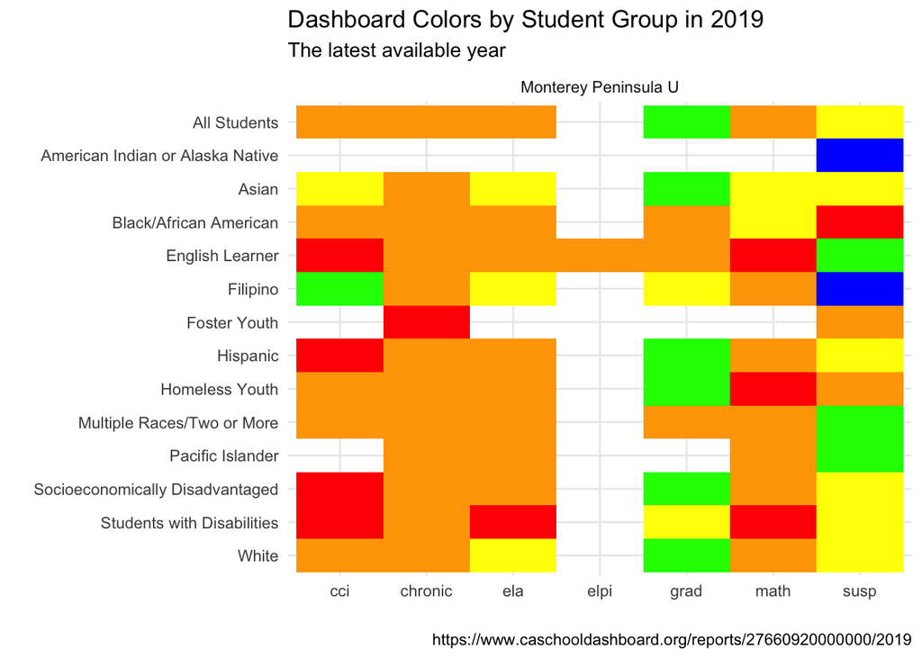

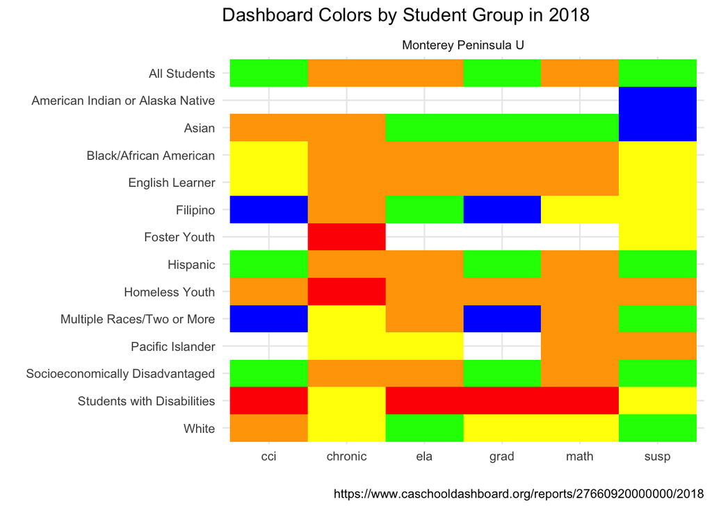

## Qualifying Groups

This table displays which student groups qualified the district to be eligible for Differentiated Assistance in each year. Moreover, for each student group it shows which Priority Areas and associated indicator criteria for which the student group qualifies.

As a reminder, COEs must offer differentiated assistance to a school district if any student group meets the criteria for two or more LCFF priorities according to California Education Code Section 52071(c). The SSPI may intervene in a school district if three or more student groups meet the criteria for two or more LCFF priorities in three out of four consecutive years. [California’s System of Support](https://www.cde.ca.gov/sp/sw/t1/csss.asp)

| Year | name | Priority Area | Criteria |
| --- | --- | --- | --- |
| 2019 | EL | P4 | Red on ELA and Math, Red on one and Orange on other for ELA Math, Red on ELPI |
| 2019 | EL | P8 | Red on College/Career |
| 2019 | SWD | P4 | Red on ELA and Math, Red on one and Orange on other for ELA Math, Red on ELPI |
| 2019 | SWD | P8 | Red on College/Career |
| 2018 | SWD | P4 | Red on ELA and Math, Red on one and Orange on other for ELA Math, Red on ELPI |
| 2018 | SWD | P5 | Red on graduation or Red on chronic absenteeism |
| 2018 | SWD | P8 | Red on College/Career |

## Historical Graphs for Eligible Groups

These graphs represent all of the indicators from Priority Areas that qualified the district in 2018 or 2019. I’ve included all qualifying subgroups on each graph, whether this was a qualifying indicator or not, as well as the All Students group for comparisons.

**Display graphs**

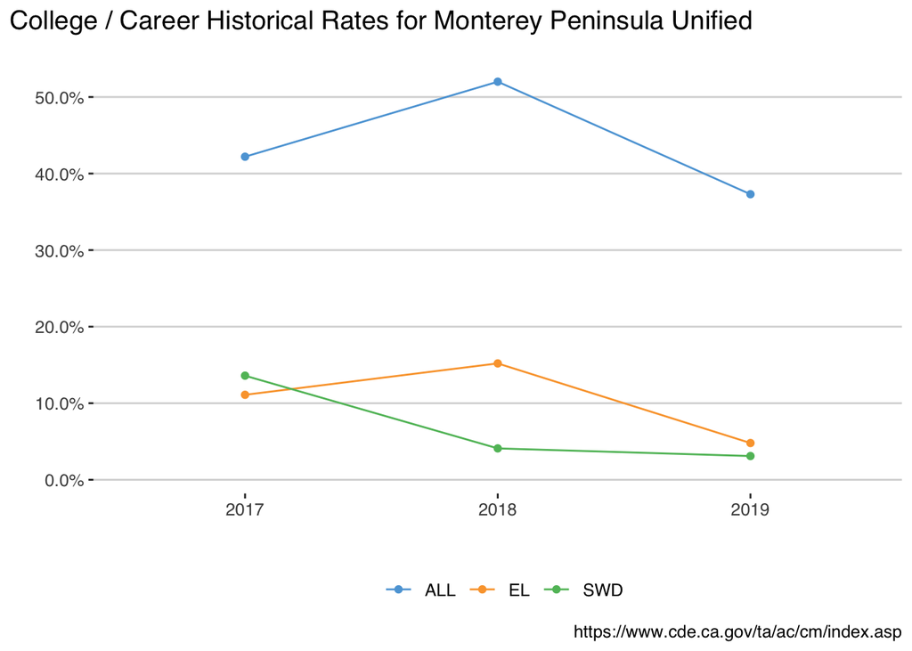

For College / Career you can see a difference between the student groups. For example, ALL is above SWD by 34.2 percentage points.

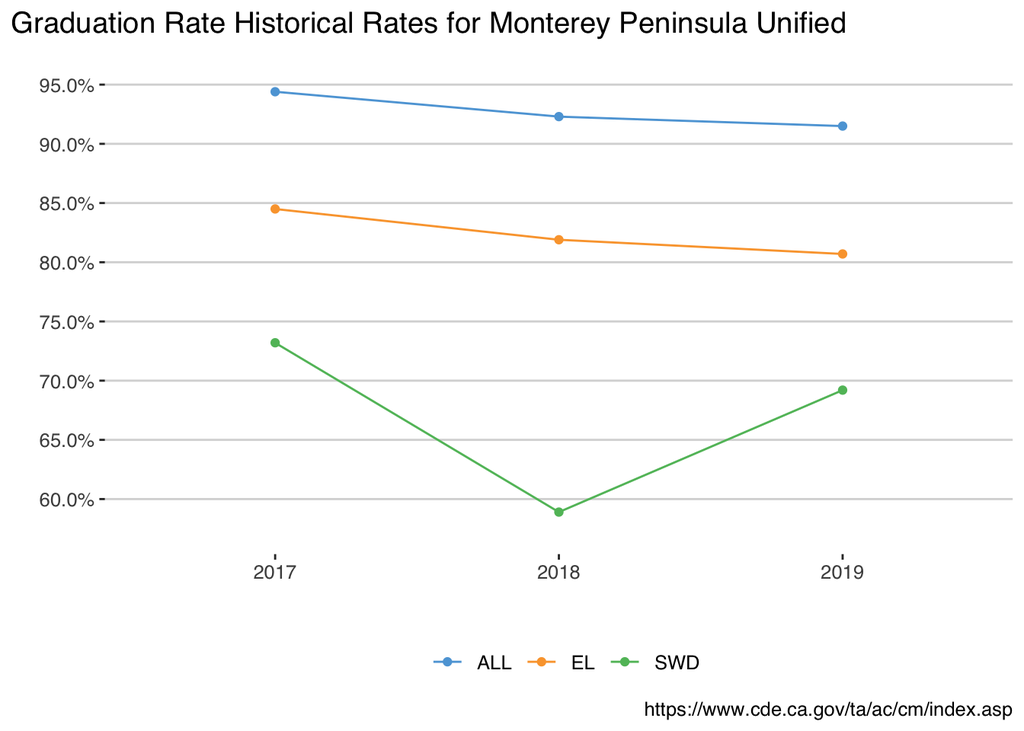

For Graduation Rate you can see a difference between the student groups. For example, ALL is above SWD by 22.3 percentage points.

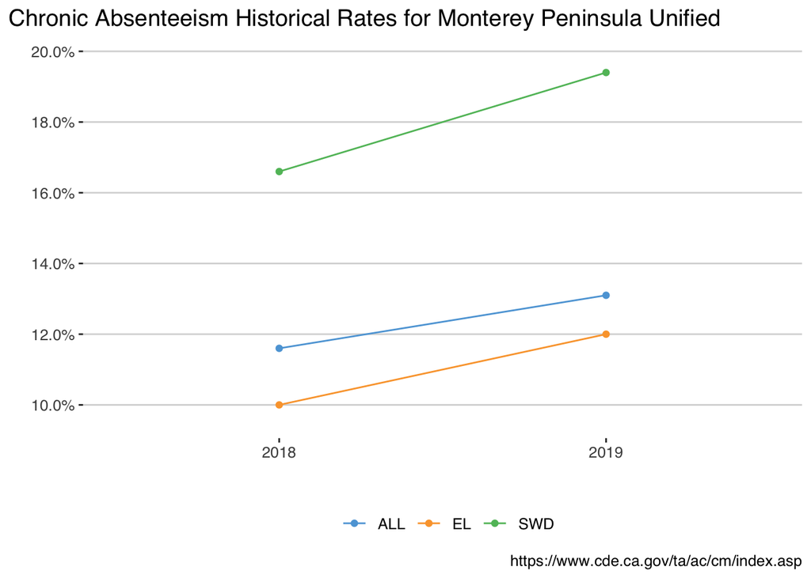

For Chronic Absenteeism you can see a difference between the student groups. For example, SWD is above EL by 7.4 percentage points.

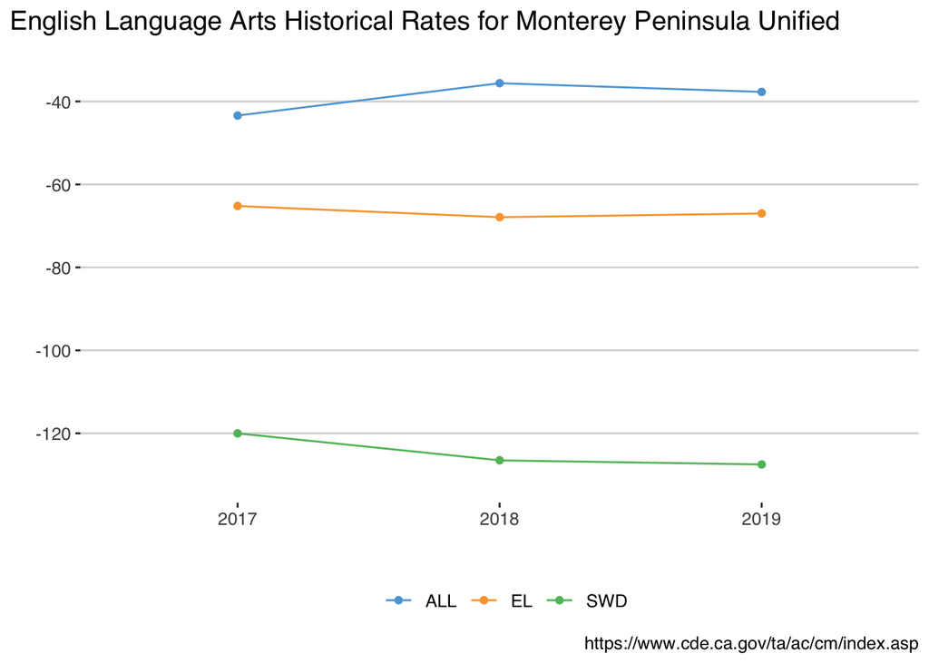

For English Language Arts you can see a difference between the student groups. For example, ALL is above SWD by 89.8 points.

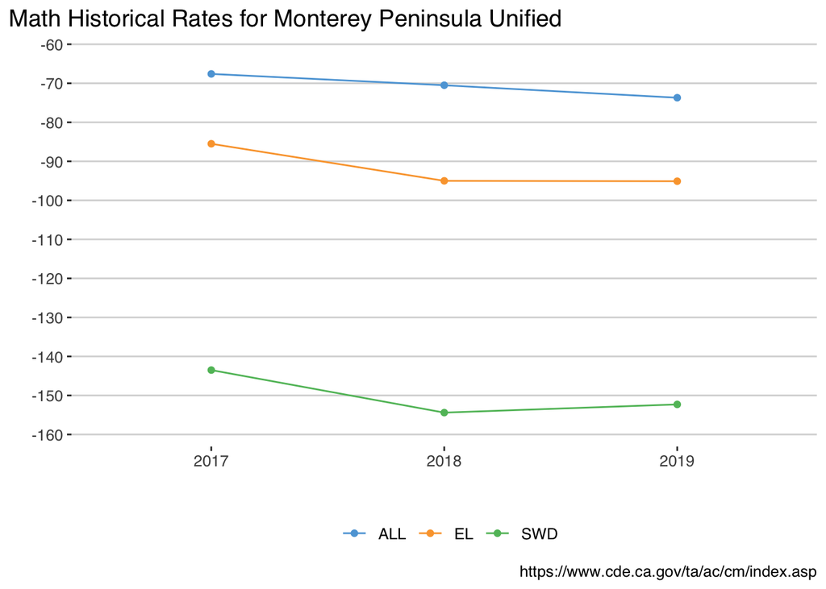

For Math you can see a difference between the student groups. For example, ALL is above SWD by 78.6 points.

## Status Needed to Exit DA in 2022

This section attempts to identify the limit on the number of students for relevant indicators to receive an orange or higher indicator in the 2022 Dashboard. The thresholds below are based on the Very Low status on the 5x5 grids used in 2019 and the number of students in the calculation in 2019. State policies may change cutpoints and the student population may shift from 2019.

| Indicator | Threshold | Summary | Target |
| --- | --- | --- | --- |
| cci | 0.099 | EL =~ 13 / 124 | EL should have higher than 13 students qualify based on the count in 2019 of 124 to not be in Red. |
| cci | 0.099 | SWD =~ 7 / 65 | SWD should have higher than 7 students qualify based on the count in 2019 of 65 to not be in Red. |
| grad | 0.68 | EL =~ 85 / 124 | EL should have higher than 85 students qualify based on the count in 2019 of 124 to not be in Red. |
| grad | 0.68 | SWD =~ 45 / 65 | SWD should have higher than 45 students qualify based on the count in 2019 of 65 to not be in Red. |
| chronic | 0.2 | SWD =~ 161 / 806 | SWD should have lower than 161 students qualify based on the count in 2019 of 806 to not be in Red. |
| chronic | 0.2 | EL =~ 480 / 2401 | EL should have lower than 480 students qualify based on the count in 2019 of 2401 to not be in Red. |

| Indicator | Threshold | Summary | Target |
| --- | --- | --- | --- |
| ela | -70.1 | Each student group | Each student group should have a Distance from Standard (DFS) of higher than -70.1 to not be in Red |
| math | -95.1 | Each student group | Each student group should have a Distance from Standard (DFS) of higher than -95.1 to not be in Red |
| elpi | 35% | EL =~ 662 / 1891 | EL should have more than 662 students qualify based on the count in 2019 of 1891 to not be in Red. |

## 2020 and 2021 Pandemic Data for Eligible Groups

This section represents the 2020 and 2021 Pandemic Era data that would be beneficial to review when making plans as well is specified in AB 130 as data to use in DA. This data is held by the district and has not been publicly shared through CDE.

**Display details**

- Assessment data for 2020-21
- Results from school climate surveys
- Course access data
- Teacher assignment information
- Pupil engagement, with a focus on locally collected data on pupil classroom attendance and engagement
- Annual IEP meetings
- Assessments for eligibility for special education services
- Implementation of integrated and designated ELD instruction

This report was generated at 2022-05-10 08:59:26.

It was developed by [David Dobrowski](https://github.com/dobrowski) at the [Monterey County Office of Education](https://www.montereycoe.org/)